# v4

# 1. Introduction

This report presents a complete simulation and analysis pipeline for a staggered Difference-in-Differences (DiD) study. We employ a modern methodological approach, using Inverse Probability Weighting (IPW) to control for observational confounding and fitting a Bayesian event-study model to estimate dynamic treatment effects, following the principles outlined by Callaway & Sant’Anna (2021).

```r
# Load all necessary libraries for the analysis.
# Messages from loading are hidden by the global setup options.
library(brms)
library(did)
library(cobalt)
library(tidyverse)
library(here)
```

# 2. Data Simulation

First, we generate a synthetic panel dataset from scratch. This allows us to know the true treatment effect and assess our model’s ability to recover it. The simulation creates a balanced panel with unit and time-specific effects, a known confounder, and a pre-defined, sustained treatment effect.

```r
set.seed(12345)

# Simulation Parameters
n_ids <- 2000
time_periods <- 6
effect_scale <- 1.5
INTERCEPT <- 2
BETA_X <- 0.5
confounder_strength <- 0.15 # Confounding is intentionally weak for good balance

# Create a balanced panel structure
panel_structure <- tidyr::expand_grid(
  id = 1:n_ids,
  period = 1:time_periods
)

# Create time-invariant (unit-level) characteristics
unit_data <- tibble(
  id = 1:n_ids,
  G = sample(c(0, 2, 3, 4, 5, 6), size = n_ids, replace = TRUE, prob = c(0.4, 0.15, 0.15, 0.15, 0.15, 0.15)),
  X = rnorm(n_ids, mean = G * confounder_strength, sd = 1),
  eta_id = rnorm(n_ids, mean = 0, sd = 2)
)

# Generate the final dataset with a sustained treatment effect
data_df <- panel_structure %>%
  left_join(unit_data, by = "id") %>%
  mutate(tau_period = rnorm(n(), mean = period * 0.5, sd = 0.2)) %>%
  mutate(is_treated_post = ifelse(G > 0 & period >= G, 1, 0)) %>%
  mutate(
    Y = INTERCEPT + eta_id + tau_period + (BETA_X * X) + (effect_scale * is_treated_post) + rnorm(n(), sd = 1.5)
  )

cat(paste("Generated a clean, balanced panel with", nrow(data_df), "rows.\n"))
```

```
## Generated a clean, balanced panel with 12000 rows.
```

# 3. Covariate Balancing via IPW

Our simulation includes a confounder, `X`, which is correlated with treatment assignment `G`. To obtain an unbiased estimate of the treatment effect, we must adjust for this confounding. We use Inverse Probability Weighting, a method that uses a model of the treatment assignment process to re-weight the sample, creating a pseudo-population where the confounder is no longer associated with the treatment.

```r
# --- 3. Covariate Balancing via IPW ---

# First, we fit a model to estimate the probability of belonging to each cohort.
propensity_data <- data_df %>%
  distinct(id, G, X) %>%
  mutate(G_factor = factor(G))

# Fit a multinomial model. We've changed the filename to force a re-fit.
propensity_model <- brm(
  formula = G_factor ~ poly(X, 2),
  data = propensity_data,
  family = categorical(),
  cores = 4,
  seed = 12345,
  silent = 2,

  file = here::here("propensity_model_poly.rds")
  # ---
)

# Next, we calculate the weights based on the newly fitted model's predictions.
prop_scores <- fitted(propensity_model, newdata = propensity_data, summary = FALSE)

propensity_data$prop_score <- purrr::map_dbl(1:nrow(propensity_data), function(i) {
  actual_cohort_level <- which(levels(propensity_data$G_factor) == propensity_data$G_factor[i])
  mean(prop_scores[, i, actual_cohort_level])
})

propensity_data <- propensity_data %>%
  mutate(ipw_weight = 1 / prop_score)

# To improve stability, we trim extreme weights at the 99th percentile.
weight_cap <- quantile(propensity_data$ipw_weight, 0.99, na.rm = TRUE)
propensity_data <- propensity_data %>%
  mutate(ipw_weight_trimmed = ifelse(ipw_weight > weight_cap, weight_cap, ipw_weight))

# Finally, we merge the weights back into our main analysis dataset.
data_weighted <- data_df %>%
  left_join(propensity_data %>% select(id, ipw_weight_trimmed), by = "id")

cat("\n--- IPW chunk complete. A fresh propensity score model was fitted. ---\n")
```

```
##
## --- IPW chunk complete. A fresh propensity score model was fitted. ---
```

## 3.1. Balance Assessment

A critical step is to verify that the weighting procedure was successful. An effective weighting scheme should produce a balanced sample where the distribution of `X` is similar across all treatment cohorts. We check this both with a summary table and visually.

```r
# The bal.tab function provides a numerical summary of the balance.
balance_assessment <- bal.tab(
  G ~ X,
  data = data_weighted,
  weights = list(Weighted = "ipw_weight_trimmed"),
  method = "weighting",
  un = TRUE
)

print(balance_assessment)
```

```
## Balance Measures
##      Type Corr.Un Corr.Adj
## X Contin.  0.3483   0.0174
##
## Effective sample sizes
##               Total
## Unadjusted 12000.
## Adjusted    9637.11
```

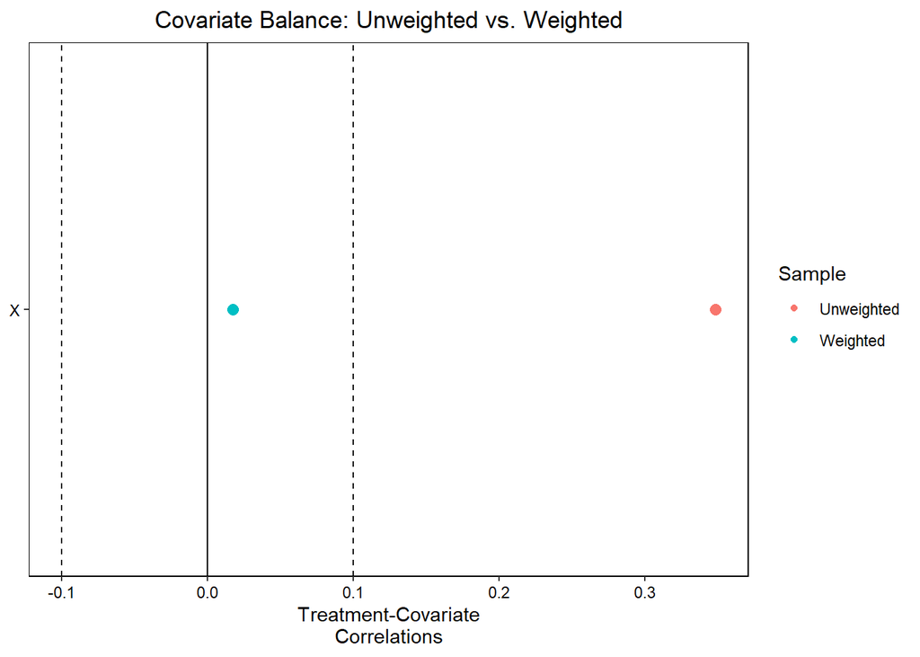

Figure 1: The Love Plot shows that after weighting, the correlation between the covariate X and treatment assignment is nearly zero, indicating excellent balance.

```r
love.plot(
  balance_assessment,
  threshold = 0.1,
  title = "Covariate Balance: Unweighted vs. Weighted",
  sample.names = c("Unweighted", "Weighted"),
  stars = "raw"
)
```

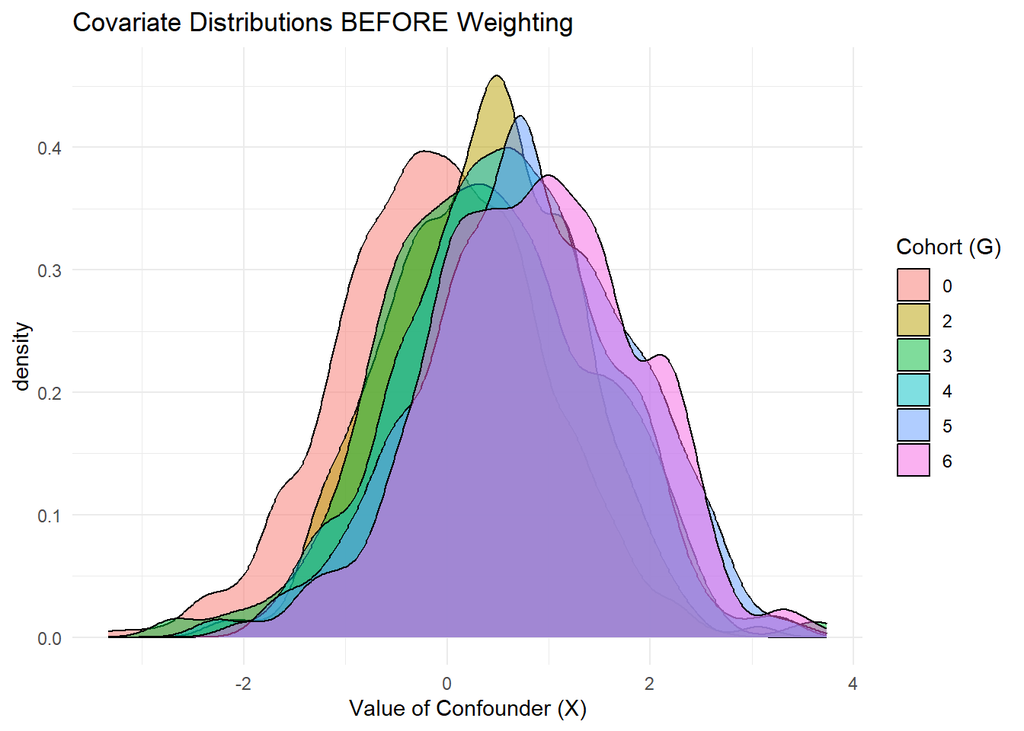

Figure 2: The density plots confirm our success. Before weighting (top), the distributions of X differed across cohorts. After weighting (bottom), the distributions are nearly identical.

```r
# We can also visualize the distributions directly.
plot_before <- ggplot(data_weighted, aes(x = X, fill = factor(G))) +
  geom_density(alpha = 0.5) +
  labs(title = "Covariate Distributions BEFORE Weighting", x = "Value of Confounder (X)", fill = "Cohort (G)") +
  theme_minimal()

plot_after <- ggplot(data_weighted, aes(x = X, fill = factor(G), weight = ipw_weight_trimmed)) +
  geom_density(alpha = 0.5) +
  labs(title = "Covariate Distributions AFTER Weighting", x = "Value of Confounder (X)", fill = "Cohort (G)") +
  theme_minimal()

print(plot_before)
```

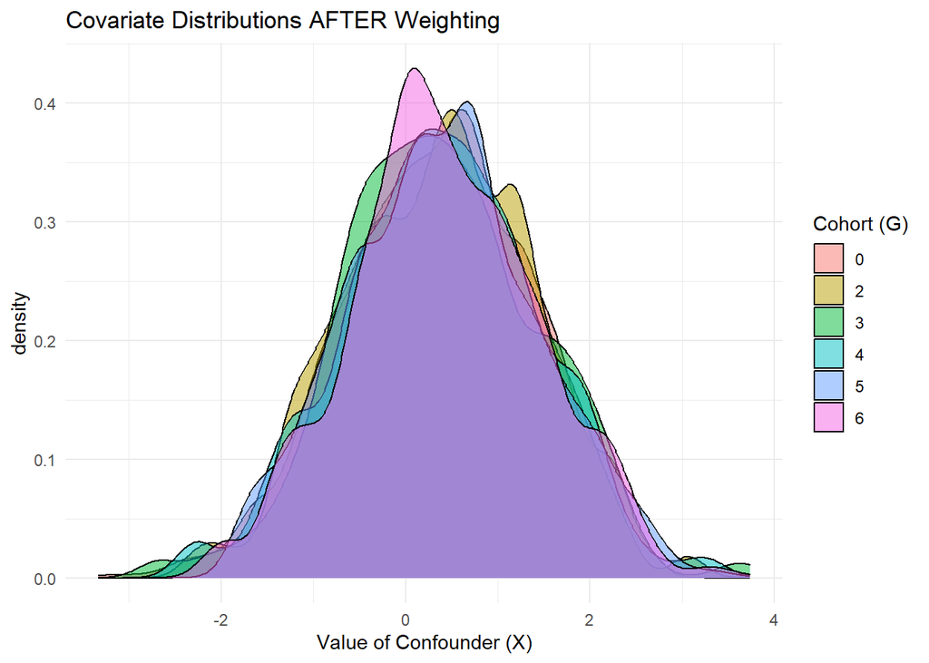

Figure 2: The density plots confirm our success. Before weighting (top), the distributions of X differed across cohorts. After weighting (bottom), the distributions are nearly identical.

```r
print(plot_after)
```

# 4. Final DiD Model and Results

With a well-balanced sample, we can proceed to the final outcome model. We fit a Bayesian event-study model to estimate the dynamic treatment effects.

```r
# Prepare the data with a factor for event time (time relative to treatment).
data_for_event_study <- data_weighted %>%
  mutate(
    event_time = case_when(
      G == 0 ~ "Never Treated",
      period < G ~ "Pre-treatment",
      period >= G ~ as.character(period - G)
    ),
    event_time = factor(event_time, levels = c("Pre-treatment", "Never Treated", "0", "1", "2", "3", "4"))
  )

# Fit the dynamic event-study model.
brm_event_study_fit <- brm(
   formula = Y | weights(ipw_weight_trimmed) ~ (1|id) + factor(period) + event_time,
   data = data_for_event_study,
   family = gaussian(),
   prior = c(prior(normal(0, 2.5), class = "b"), prior(normal(3, 2), class = "Intercept")),
   control = list(adapt_delta = 0.98, max_treedepth = 12),
   iter = 4000,
   cores = 4,
   seed = 12345,
   file = here::here("brm_event_study_fit.rds")
)

print(summary(brm_event_study_fit))
```

```
##  Family: gaussian
##   Links: mu = identity; sigma = identity
## Formula: Y | weights(ipw_weight_trimmed) ~ (1 | id) + factor(period) + event_time
##    Data: data_for_event_study (Number of observations: 12000)
##   Draws: 4 chains, each with iter = 4000; warmup = 2000; thin = 1;
##          total post-warmup draws = 8000
##
## Group-Level Effects:
## ~id (Number of levels: 2000)
##               Estimate Est.Error l-95% CI u-95% CI Rhat Bulk_ESS Tail_ESS
## sd(Intercept)     2.10      0.03     2.04     2.17 1.01      268      813
##
## Population-Level Effects:
##                        Estimate Est.Error l-95% CI u-95% CI Rhat Bulk_ESS
## Intercept                  2.80      0.06     2.69     2.91 1.02      185
## factorperiod2              0.56      0.02     0.53     0.60 1.00     9186
## factorperiod3              0.97      0.02     0.93     1.01 1.00     6618
## factorperiod4              1.49      0.02     1.45     1.53 1.00     4497
## factorperiod5              1.95      0.02     1.90     2.00 1.00     3461
## factorperiod6              2.46      0.03     2.40     2.51 1.00     3208
## event_timeNeverTreated    -0.32      0.10    -0.51    -0.12 1.01      232
## event_time0                1.56      0.02     1.52     1.60 1.00     4556
## event_time1                1.54      0.02     1.50     1.59 1.00     3966
## event_time2                1.64      0.03     1.58     1.70 1.00     3838
## event_time3                1.49      0.04     1.42     1.57 1.00     3507
## event_time4                1.55      0.05     1.46     1.65 1.00     4223
##                        Tail_ESS
## Intercept                   283
## factorperiod2              6957
## factorperiod3              6931
## factorperiod4              5869
## factorperiod5              5677
## factorperiod6              4777
## event_timeNeverTreated      704
## event_time0                5691
## event_time1                5150
## event_time2                5667
## event_time3                5212
## event_time4                5136
##
## Family Specific Parameters:
##       Estimate Est.Error l-95% CI u-95% CI Rhat Bulk_ESS Tail_ESS
## sigma     1.40      0.00     1.39     1.41 1.00    13612     4515
##
## Draws were sampled using sampling(NUTS). For each parameter, Bulk_ESS
## and Tail_ESS are effective sample size measures, and Rhat is the potential
## scale reduction factor on split chains (at convergence, Rhat = 1).
```

## 4.1. Visualizing the Treatment Effects

The primary result of our analysis is the event-study plot. It shows the estimated treatment effect for each period relative to the treatment’s start date, allowing us to see how the effect evolves over time.

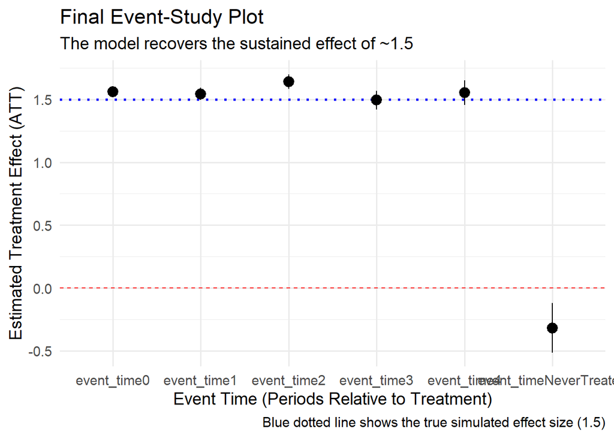

```r
# Extract coefficients for plotting.
att_estimates <- as.data.frame(summary(brm_event_study_fit)$fixed) %>%
  tibble::rownames_to_column("term") %>%
  filter(stringr::str_detect(term, "event_time"))

# Create the final visualization.
final_plot <- ggplot(att_estimates, aes(x = term, y = Estimate, ymin = `l-95% CI`, ymax = `u-95% CI`)) +
  geom_hline(yintercept = 0, linetype = "dashed", color = "red") +
  geom_hline(yintercept = effect_scale, linetype = "dotted", color = "blue", linewidth = 1) +
  geom_pointrange(color = "black", size = 0.8) +
  labs(
    title = "Final Event-Study Plot",
    subtitle = "The model recovers the sustained effect of ~1.5",
    x = "Event Time (Periods Relative to Treatment)",
    y = "Estimated Treatment Effect (ATT)",
    caption = "Blue dotted line shows the true simulated effect size (1.5)"
  ) +
  theme_minimal(base_size = 14)

print(final_plot)
```